# Homework6

Sana Khan

2022-11-14

I completed this homework with the help of the textbook.

1. **Thedatasetspackage(installedinRbydefault)containsadatasetcalledInsectSprays that shows the results of an experiment with six different kinds of insecticide. For each kind of insecticide, n = 12 observations were conducted. Each observation repre‐ sented the count of insects killed by the spray. In this experiment, what is the depen‐ dent variable (outcome) and what is the independent variable? What is the total number of observations?**

```r
summary(InsectSprays)
```

```
##      count       spray
##  Min.   : 0.00   A:12
##  1st Qu.: 3.00   B:12
##  Median : 7.00   C:12
##  Mean   : 9.50   D:12
##  3rd Qu.:14.25   E:12
##  Max.   :26.00   F:12
```

```r
str(InsectSprays)
```

```
## 'data.frame':    72 obs. of  2 variables:
##  $ count: num  10 7 20 14 14 12 10 23 17 20 ...
##  $ spray: Factor w/ 6 levels "A","B","C","D",..: 1 1 1 1 1 1 1 1 1 1 ...
```

The dependent variable in this experiment is the number of insects killed and the independent variable is the insect spray being used. There are 72 observations.

2.**After running the aov() procedure on the InsectSprays data set, the “Mean Sq” for spray is 533.8 and the “Mean Sq” for Residuals is 15.4. Which one of these is the between‐ groups variance and which one is the within‐groups variance? Explain your answers briefly in your own words.**

```
##             Df Sum Sq Mean Sq F value Pr(>F)
## spray        5   2669   533.8    34.7 <2e-16 ***
## Residuals   66   1015    15.4
## ---
## Signif. codes:  0 '***' 0.001 '**' 0.01 '*' 0.05 '.' 0.1 ' ' 1
```

In this experiment, 533.8 is the between- groups variance and 15.4 is the within-groups variance. Between groups variance is the variance between each group and the overall mean. Within groups variance is the variance within each group and that groups means.

3. **Based on the information in question 2 and your response to that question, calculate an F‐ratio by hand or using a calculator. Given everything you have earned about F‐ratios, what do you think of this one? Hint: If you had all the information you needed for a Null Hypothesis Significance Test, would you reject the null? Why or why not?**

F-ratio: 533.8/ 15.4 = 34.66. This F-ratio is large, which means there is variation between our groups. We also have a low p-value so we would reject the null hypothesis further proving there is significance among the groups.

4. **Continuing with the InsectSprays example, there are six groups where each one has n = 12 observations. Calculate the degrees of freedom between groups and the degrees of freedom within groups. Explain why the sum of these two values adds up to one less than the total number of observations in the data set**.

The degrees of freedom for between groups is 5, and the degrees of freedom for within groups is 66. The sum of these two values (71) add up to less than the total number of observations (72) because we always lose one degree of freedom by calculating the grand mean.

5. **Use R or R‐Studio to run the aov() command on the InsectSprays data set. You will have to specify the model correctly using the “~” character to separate the dependent variable from the independent variable. Place the results of the aov() command into a new object called insectResults. Run the summary() command on insectResults and interpret the results briefly in your own words. As a matter of good practice, you should state the null hypothesis, the alternative hypothesis, and what the results of the null hypothesis significance test lead you to conclude.**

```r
insectResults <- aov(count ~ spray, data = InsectSprays)
summary(insectResults)
```

```
##             Df Sum Sq Mean Sq F value Pr(>F)
## spray        5   2669   533.8    34.7 <2e-16 ***
## Residuals   66   1015    15.4
## ---
## Signif. codes:  0 '***' 0.001 '**' 0.01 '*' 0.05 '.' 0.1 ' ' 1
```

The insectResults variable is showing the outcome of the experiment,which is to test which spray performed the best. The null hypothesis would be that there is no difference in the means among the sprays. The alternative hypothesis is that there is a difference in the means, showing that some of the groups performed better than others. The F-value is high and our p-value is less than alpha (.05) which supports rejecting the null hypothsis.

6. **Load the BayesFactor package and run the anovaBF() command on the InsectSprays data set. You will have to specify the model correctly using the “~” character to sepa‐ rate the dependent variable from the independent variable. Produce posterior distribu‐ tions with the posterior() command and display the resulting HDIs. Interpret the results briefly in your own words, including an interpretation of the BayesFactor produced by the grouping variable. As a matter of good practice, you should state the two hypoth‐ eses that are being compared. Using the rules of thumb offered by Kass and Raftery (1995), what is the strength of this result?**

```r
library("BayesFactor")
library("BEST")
```

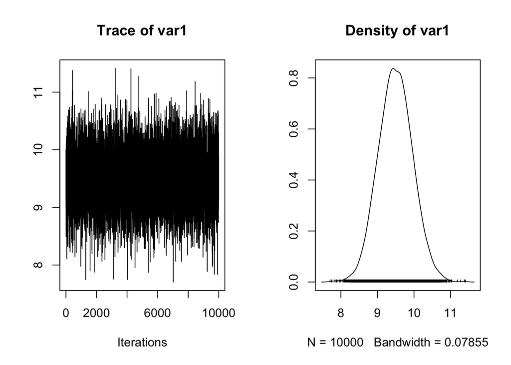

```r
spraysBayesOut <- anovaBF(count ~ spray, data=InsectSprays)
mcmcOut <- posterior(spraysBayesOut,iterations=10000)
plot(mcmcOut[,"mu"])
```

```r
spraysBayesOut
```

```
## Bayes factor analysis
## --------------
## [1] spray : 1.506706e+14 ±0%
##
## Against denominator:
##   Intercept only
## ---
## Bayes factor type: BFlinearModel, JZS
```

The HDI shows that the grand mean is between 8 and 11, with the highest density at 9.5. The null hypothesis is that there is not a difference among the spray’s used on the different groups, and the alternative hypothesis is that there is a difference. The Bayes factor is also above 1, which shows that we can reject the null hypothesis.

7. In situations where the alternative hypothesis for an ANOVA is supported and there are more than two groups, it is possible to do post‐hoc testing to uncover which pairs of groups are substantially different from one another. Using the InsectSprays data, conduct a t‐test to compare groups C and F (preferably a Bayesian t‐test). Interpret the results of this t‐test.

```
## Waiting for parallel processing to complete...done.
```

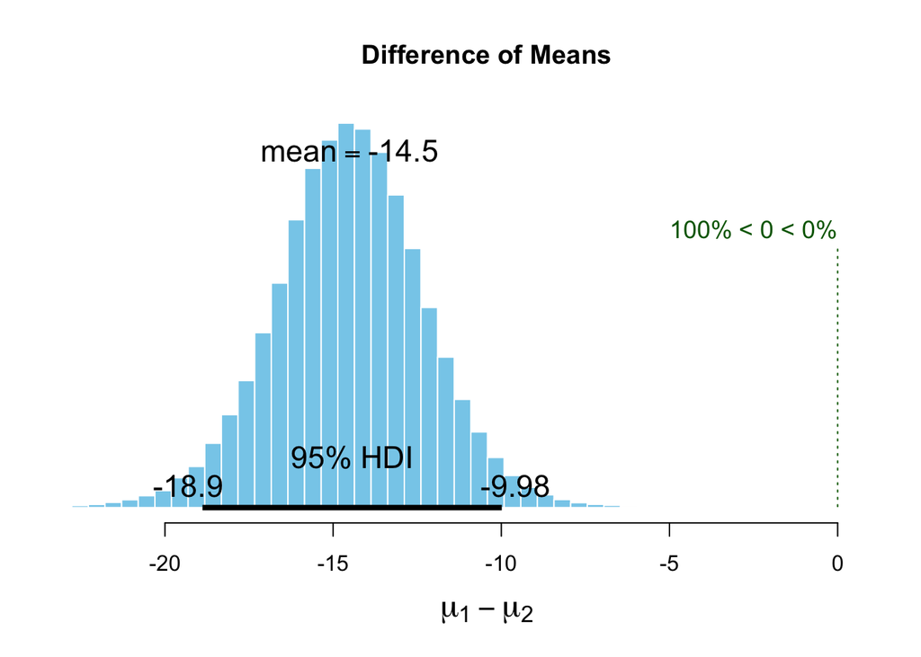

```r
CandF_obs <- InsectSprays[InsectSprays$spray=="C" | InsectSprays$spray=="F",]
sprayC_obs <- InsectSprays[InsectSprays$spray=="C",1]
sprayF_obs <- InsectSprays[InsectSprays$spray=="F",1]
obs <-data.frame("C" = sprayC_obs, ".F" = sprayF_obs)

# Performa a Bayes t-test against just the C and F sprays.
plot(BESTmcmc(InsectSprays[InsectSprays$spray=="C",1],
              InsectSprays[InsectSprays$spray=="F",1]))
```

```r
spray_BFOut <- anovaBF(count ~ spray, data=CandF_obs)
summary(spray_BFOut)
```

```
## Bayes factor analysis
## --------------
## [1] spray : 90005.78 ±0%
##
## Against denominator:
##   Intercept only
## ---
## Bayes factor type: BFlinearModel, JZS
```

We can see from the HDI plot that the mostly likely difference in means between groups C & F is -14.5. 95% of the difference in means is between -10 and -19. Since the mean difference does not cross 0, and the Bayes Factor test has odds of 90005:1, Spray F performs better than C